# Extreme Subgroup Effects Under a Uniform Treatment Benefit

A Simulation Study Based on Observed Trial Data

Author

Larry F. León

Published

May 19, 2026

# 1 Overview

A central concern in exploratory subgroup analysis is the potential for **extreme results driven entirely by chance**, not by genuine treatment effect heterogeneity. When many subgroups are examined in a single dataset — as is routine in regulatory submissions and trial reports — small subgroups in particular can produce hazard ratio estimates that look dramatic simply because they are noisy. The smaller the subgroup, the wider the confidence interval, and the higher the probability that the upper bound strays far from the truth.

This vignette evaluates that risk directly. We generate thousands of synthetic trials from a data generating mechanism (DGM) with a **perfectly uniform treatment benefit** — the true hazard ratio is identical for every patient — and ask: how often do standard Cox model analyses produce extreme subgroup results?

The vignette is organised as a complete, self-contained workflow:

1. **Building the DGM** — fitting a Weibull AFT model to real data, constructing a super-population, and calibrating the censoring process so that simulated trials reproduce the censoring pattern of the source data. This step establishes the uniform-effect scenario: a DGM where the true HR is 0.70 *for every patient*, with no subgroup differential effects.
2. **Running simulated trials** — drawing 100 synthetic trial replicates from the uniform DGM and fitting a stratified Cox model in each pre-defined subgroup.
3. **Characterising the distribution of extreme results** — for each subgroup, summarising how variable the HR point estimate is across simulations (the empirical 99% CI, or ECI) and how large the upper confidence bound UB(HR) can become by chance alone. Random benchmark subgroups (`random15`, `random20`, `random40`, `random60`) with no clinical meaning serve as calibration anchors, making explicit that clinical subgroups of the same size are statistically indistinguishable from meaningless random groupings.

All examples use the GBSG breast cancer dataset (`survival::gbsg`).

## 1.1 Example of Subgroups Under Study

For the study under question, the subgroups and features (size, events, etc) are of course specific to that study. While we are using the GBSG breast cancer study as the case-study, the analyses can be applied or modified based on any study.

An example of pre-defined subgroups, ranging from clinically motivated subpopulations to deliberately artificial ones:

| Subgroup | Basis | Approximate N |
| --- | --- | --- |
| All Patients (ITT) | Full trial | ~700 |
| No liver metastases | Clinical | ~400 |
| BRAF V600E mutant | Molecular | ~300 |
| Age ≤ 65 | Demographic | ~400 |
| Spain, Germany, UK | Country/region | ~60–150 |
| Asia Pacific region | Region | ~100 |
| ECOG 0 / ECOG 1 | Performance status | ~300 each |
| **random15, random20** | **Randomly sampled** | **~15, ~20** |
| **random40, random60** | **Randomly sampled** | **~40, ~60** |

The `random*` subgroups are the key benchmark. They are constructed by randomly sampling approximately 20% of subjects and taking the first 15, 20, 40, and 60 patients:

```r
set.seed(8316951)
sg_ran <- rbinom(nrow(df_analysis), size = 1, prob = 0.2)
temp   <- cumsum(sg_ran)

sg_ran15            <- sg_ran
sg_ran15[temp > 15] <- 0   # first 15 selected subjects
df_analysis$random15 <- sg_ran15

sg_ran40            <- sg_ran
sg_ran40[temp > 40] <- 0
df_analysis$random40 <- sg_ran40
```

These subgroups have no clinical meaning whatsoever — their true HR equals the ITT HR of 0.70. Any extreme result they produce is purely a function of their small size and sampling variability.

## 1.2 Six Analysis Variants

For each simulated trial and each subgroup, six Cox model specifications are fitted, covering the range of approaches one might encounter in practice:

| Label | Model specification |
| --- | --- |
| `sR` | Stratified by original randomisation factors |
| `none` | Unstratified |
| `sX` | Stratified by ECOG status |
| `sBM*` | Stratified by biomarker above/below optimal cutpoint |
| `sX+sR` | Stratified by ECOG and randomisation factors |
| `X+O+sR` | Covariate-adjusted (ECOG, age, sex) + stratified |

## 1.3 Summary Statistics Across Simulations

For each subgroup and analysis, two quantities are accumulated across all simulated trials:

**HR point estimate distribution.** Reported as median and the 1st–99th percentile interval (the “empirical 99% confidence interval” or ECI). Under truth, the median should be close to 0.70 for every subgroup. The spread of the ECI reflects how variable the estimate is — wider for smaller subgroups.

**Upper confidence bound UB(HR).** The one-sided 97.5% upper bound of the Cox 95% confidence interval. Two key thresholds are tracked: - `UB(HR) < 1.0`: the upper bound excludes no treatment effect (nominally “significant” benefit). - `HR < 0.80`: the point estimate alone looks like a meaningful benefit (at the ITT threshold level).

Under the null of a uniform HR = 0.70 with no subgroup effects, `UB(HR) < 1.0` should occur approximately 95% of the time for the full ITT — it simply reflects power to detect the overall benefit. For subgroups, the rate falls with sample size, but the distribution of UB(HR) *among those trials where UB(HR) ≥ 1* reveals how extreme a false non-significance result can look.

We note that continuous biomarkers can also be considered. This is more involved and not necessary for uniform effects, but valuable for trials with biomarkers when there is interest in exploring the dynamics of subgroups in the presence of actual biomarker effects (correlated with other patients’ characteristics).

## 1.4 Setting: Uniform Treatment Effect

The DGM is built from a real trial dataset using `generate_aft_dgm_flex()` with a single-knot spline biomarker model. The key feature is that the true log hazard ratio is **constant across all biomarker values**:

$$\psi^0(z) = \log(\text{HR}_{\text{true}}) \quad \text{for all } z.$$

The spline parameterisation is specified via `log.hrs = log(c(hr0, hr_k, hr_z))`, where `hr0`, `hr_k`, `hr_z` are the true HRs at biomarker values 0, the knot `k`, and an upper anchor `zeta`, respectively. Under the uniform scenario all three are set to the same value:

```r
log.hrs <- log(c(0.70, 0.70, 0.70))  # uniform HR = 0.70 everywhere
dgm     <- get_dgm_stratified(
  df        = df_analysis,
  knot      = 40,
  kappa     = 50,
  hrs       = c(0.70, 0.70, 0.70),
  strata_tte = "strataNew"
)
```

## 1.5 Installation

The **forestsearch** package can be installed directly from GitHub using either `pak` (recommended) or `remotes`.

### 1.5.1 Stable development version (default branch)

```r
# Using pak (recommended)
# install.packages("pak")
pak::pak("larry-leon/forestsearch")

# Using remotes
# install.packages("remotes")
remotes::install_github("larry-leon/forestsearch")
```

### 1.5.2 `feature/glm-extension` branch (optional)

As of **May 19, 2026**, the most up-to-date functionality is available on the **`feature/glm-extension`** branch. This branch extends the survival simulation framework to binary, continuous, and count outcomes (logistic, Gaussian, and Poisson GLMs) and includes additional functions such as `generate_glm_dgm()`, `simulate_from_glm_dgm()`, `calibrate_glm_interaction()`, and GLM dispatch in `run_simulation_analysis()`. Users who want access to the latest features can install from this branch:

```r
# Using pak (recommended)
pak::pak("larry-leon/forestsearch@feature/glm-extension")

# Using remotes
remotes::install_github("larry-leon/forestsearch",
                        ref = "feature/glm-extension")
```

To verify the branch is loaded after installation:

```r
packageVersion("forestsearch")
# Confirm that GLM functions are exported:
exists("generate_glm_dgm", where = asNamespace("forestsearch"))
```

The package depends on [**weightedsurv**](https://github.com/larry-leon/weightedsurv), which is installed automatically from GitHub via the `Remotes` field in `DESCRIPTION` — no separate step is needed.

Once installed, load the package in the usual way:

```r
library(forestsearch)
```

## 1.6 Documentation

Full documentation, including function reference and vignettes, is available at the **pkgdown** site:

> https://larry-leon.github.io/forestsearch/

The site includes, **along with this vignette**:

- **Getting Started** — end-to-end walkthrough with the GBSG breast cancer trial (`vignette("forestsearch")`)
- **Methodology** — statistical framework, algorithm details, and simulation results (`vignette("methodology")`)
- **Treatment Effect Definitions** — marginal HR, average hazard ratio (AHR), and controlled direct effect (CDE) estimands
- **Simulation Studies** — operating characteristics and published benchmarks
- **Reference** — all exported functions organised across 16 topic areas

Vignettes can also be accessed locally after installation:

```r
vignette("forestsearch")   # Getting Started
vignette("methodology")    # Statistical methodology
```

# 2 Setup

```r
library(forestsearch)
library(survival)
library(ggplot2)
library(dplyr)
library(patchwork)     # assembles gg_forest() panels

theme_set(theme_minimal(base_size = 12))
```

```r
# Load GBSG data and convert time to months (DGM time scale)
data(gbsg, package = "survival")

gbsg$time_months <- gbsg$rfstime / 30.4375
gbsg$treat        <- gbsg$hormon

cat("N =", nrow(gbsg), "  Events:", sum(gbsg$status),
    sprintf("(%.0f%%)", 100 * mean(gbsg$status)), "\n")
```

```
N = 686   Events: 299 (44%)
```

```r
cat("Median follow-up (months):",
    round(median(gbsg$time_months), 1), "\n")
```

```
Median follow-up (months): 35.6
```

```r
cat("Median event time (months):",
    round(median(gbsg$time_months[gbsg$status == 1]), 1), "\n")
```

```
Median event time (months): 21.2
```

# 3 Part I — Building the Uniform-Effect Data Generating Mechanism

To evaluate extreme subgroup effects by chance, we need a DGM where the treatment has a genuine, uniform benefit — so that any subgroup finding is definitionally a false positive. This section constructs that DGM from the GBSG data using `generate_aft_dgm_flex()` with `model = "null"` (uniform treatment effect throughout; no embedded harm subgroup).

## 3.1 Why time-scale consistency matters first

Before fitting anything, confirm that all time parameters are expressed in the same units. The single most common simulation failure is building the DGM on days (e.g. `rfstime`) and then passing `analysis_time` in months. The result is a follow-up window far shorter than the DGM event-time distribution, producing universal administrative censoring (`event_sim = 0` for every subject).

After building the DGM, this quick check catches the problem:

```r
# exp(mu) is the implied median event time on the DGM time scale.
# It should be close to the observed median event time in months.
cat("Observed median event time (months):",
    round(median(gbsg$time_months[gbsg$status == 1]), 1), "\n")
```

```
Observed median event time (months): 21.2
```

```r
cat("(After building dgm_uniform, exp(dgm_uniform$model_params$mu) should be similar.)\n")
```

```
(After building dgm_uniform, exp(dgm_uniform$model_params$mu) should be similar.)
```

## 3.2 Fitting `generate_aft_dgm_flex()`

`generate_aft_dgm_flex()` fits a Weibull AFT model to the source data and generates a large *super population* from which all future trials will be drawn. For the extreme-subgroup evaluation we use `model = "null"`, which sets the treatment effect to be identical for every patient — there is no subgroup, so any apparent finding is a false positive by construction.

The censoring model is estimated from the data by AIC-based selection across Weibull and log-normal models, with and without covariate adjustment. The next section shows how to verify and calibrate this so that simulated trials reproduce the censoring pattern of the source data.

**Note.** The DGM built here has a uniform treatment effect — no embedded subgroup. For a contrasting example with a true HTE (a harm subgroup defined by ER-low & pre-menopausal status), see the **Appendix: DGM with Heterogeneous Treatment Effects** at the end of this document.

```r
.t_dgm_start <- Sys.time()

set.seed(99)

dgm_uniform <- generate_aft_dgm_flex(
  # ── Required: source data & outcome ─────────────────────────────────────
  data                = gbsg,
  continuous_vars     = c("age", "size", "nodes", "pgr", "er"),
  factor_vars         = c("meno", "grade"),
  outcome_var         = "time_months",
  event_var           = "status",
  # ── Treatment ───────────────────────────────────────────────────────────
  treatment_var       = "hormon",
  draw_treatment      = FALSE,                                  # default
  # ── HTE specification — uniform treatment effect, no embedded subgroup ──
  model               = "null",                                 # uniform HR throughout
  subgroup_vars       = NULL,                                   # default — no embedded HTE
  subgroup_cuts       = NULL,                                   # default
  k_treat             = 1,                                      # default
  k_inter             = 1,                                      # default (irrelevant under "null")
  spline_spec         = NULL,                                   # default
  set_beta_spec       = list(set_var = NULL, beta_var = NULL),  # default
  # ── Censoring model (independent of treatment effect) ───────────────────
  continuous_vars_cens = NULL,                                  # default → inherit
  factor_vars_cens     = NULL,                                  # default → inherit
  select_censoring     = TRUE,                                  # default — AIC select
  cens_type            = "weibull",                             # default
  cens_params          = list(),                                # default
  cens_intercept_only  = FALSE,                                 # default
  # ── Super population & misc ─────────────────────────────────────────────
  n_super             = 5000,
  standardize         = FALSE,                                  # default
  seed                = 99,
  verbose             = FALSE
)

t_dgm <- as.numeric(difftime(Sys.time(), .t_dgm_start, units = "secs"))

cat("Uniform DGM  |  true overall HR:",
    round(dgm_uniform$hazard_ratios$overall, 3),
    " |  implied median event time:",
    round(exp(dgm_uniform$model_params$mu), 1), "months\n")
```

```
Uniform DGM  |  true overall HR: 0.757  |  implied median event time: 55.5 months
```

```r
# Key DGM outputs
cat("=== Uniform DGM Summary ===\n")
```

```
=== Uniform DGM Summary ===
```

```r
cat("Time scale          : months\n")
```

```
Time scale          : months
```

```r
cat("Implied median T    : exp(mu) =",
    round(exp(dgm_uniform$model_params$mu), 1), "months\n")
```

```
Implied median T    : exp(mu) = 55.5 months
```

```r
cat("True HR (overall)   :",
    round(dgm_uniform$hazard_ratios$overall, 3), "\n")
```

```
True HR (overall)   : 0.757
```

```r
cat("Causal AHR          :",
    round(dgm_uniform$hazard_ratios$AHR, 3), "\n")
```

```
Causal AHR          : 0.689
```

```r
cat("Censoring type      :",
    dgm_uniform$model_params$censoring$type, "\n")
```

```
Censoring type      : weibull
```

# 4 Part II — Censoring Diagnostics and Calibration

For the simulation results to be credible, the censoring pattern in each synthetic trial must match what was observed in the source data. If the simulated censoring rate is much higher or lower than the real one, the event counts in small subgroups will be systematically wrong, biasing the HR and UB(HR) distributions we are trying to characterise.

Even with a well-fitted censoring model, the interaction between the DGM censoring distribution and administrative censoring (the `analysis_time` cutoff) can shift the effective censoring rate substantially away from what was observed. This section covers two functions that diagnose and correct for this shift before the main simulation loop is run.

## 4.1 Simulation pipeline configuration

The simulation pipeline has a small number of parameters that govern every per-trial draw: the patients per trial, the administrative analysis time, the recruitment window, and the iteration-seed scheme. Defining them **once**, in a single `sim_config` list, means the calibration step (below), the single-trial demonstration in Part III, and the main parallel loop in Part IV all use exactly the same values — no duplication, no risk of drift. Change a field here and every downstream chunk reacts automatically.

```r
# ── Simulation pipeline configuration ──────────────────────────────────────
# Single source of truth for every per-trial parameter.  Every downstream
# call to simulate_from_dgm() and calibrate_cens_adjust() references this
# list — nothing is hard-coded twice.
sim_config <- list(
  n_per_trial      = nrow(gbsg),  # patients per simulated trial
  analysis_time    = 84,          # months — administrative censoring time
  max_entry        = 24,          # months — uniform recruitment window
  seed_base        = 0L,          # per-trial seed = seed_base + iter
  rand_seed_offset = 1e6L         # random-subgroup seed = seed + offset
)

cat("Per-trial simulation parameters\n",
    "  n per trial   :", sim_config$n_per_trial, "\n",
    "  analysis_time :", sim_config$analysis_time, "months\n",
    "  max_entry     :", sim_config$max_entry,     "months\n",
    "  seed scheme   : iter seed = ", sim_config$seed_base,
    " + ss\n", sep = "")
```

```
Per-trial simulation parameters
  n per trial   :686
  analysis_time :84months
  max_entry     :24months
  seed scheme   : iter seed = 0 + ss
```

## 4.2 Diagnosing censoring consistency

`check_censoring_dgm()` compares three censoring summaries between the DGM reference data (`dgm$df_super`) and a simulated dataset: overall censoring rate, censoring-time quantiles among censored subjects, and the KM-based median censoring time (estimated by reversing the event indicator so that censored observations become the “event” of interest).

```r
# Generate a pilot simulated trial (no calibration yet)
sim_pilot <- simulate_from_dgm(
  dgm            = dgm_uniform,
  n              = 1500,
  rand_ratio     = 1,                          # default (1:1 randomisation)
  entry_var      = NULL,                       # default (synthetic entry times)
  max_entry      = sim_config$max_entry,
  analysis_time  = sim_config$analysis_time,
  cens_adjust    = 0,                          # pilot: no calibration shift
  draw_treatment = TRUE,                       # default
  seed           = 1,
  strata_rand    = NULL,                       # default
  hrz_crit       = NULL,                       # default
  keep_rand      = FALSE,                      # default
  time_eos       = NULL                        # default
)

cat("Pilot trial:  N =", nrow(sim_pilot),
    "  Event rate:", round(mean(sim_pilot$event_sim), 3), "\n")
```

```
Pilot trial:  N = 1500   Event rate: 0.402
```

```r
diag0 <- check_censoring_dgm(
  sim_data   = sim_pilot,
  dgm        = dgm_uniform,
  treat_var  = "treat_sim",   # default
  rate_tol   = 0.10,
  median_tol = 0.25,
  verbose    = TRUE
)
```

```
=========================================================
  Censoring Diagnostic: DGM Reference vs Simulated
=========================================================
  DGM censoring type  : weibull
  DGM mu_cens         : 4.0312  [exp = 56.33 time units]
  DGM tau_cens        : 0.4246
  Reference n (super) : 5000
  Simulated n         : 1500

--- 1. Censoring Rates ---
   Group Ref_rate Sim_rate    Diff
 Overall    57.6%    59.8% +2.2 pp
   Arm 0    54.7%    53.5% -1.2 pp
   Arm 1    63.1%    66.1% +3.0 pp

--- 2. Censoring-Time Quantiles (censored subjects only) ---
    Ref: y[event == 0]  |  Sim: c_time[event_sim == 0]
 Quantile   Ref   Sim Ratio
      25% 29.31 27.71 0.945
      50% 47.34 41.51 0.877
      75% 61.04 55.93 0.916
      90% 70.83 65.49 0.925

--- 3. KM Median Censoring Time (reversed event indicator) ---
   Group Ref_median Sim_median Ratio
 Overall   54.04517   46.87203 0.867
   Arm 0   51.58111   48.26725 0.936
   Arm 1   56.80493   45.91065 0.808

--- 4. Implied Time-Scale Check ---
  exp(params$mu)          = 55.53  [median outcome time, DGM scale]
  exp(params$censoring$mu)= 56.33  [median censoring time, DGM scale]
  If these values are implausibly large relative to your
  analysis_time, the DGM was likely built on a different time
  scale (e.g. days vs months).

[OK] No substantial discrepancies detected.
=========================================================
```

**Reading the output.** Flags warn when the absolute censoring-rate discrepancy exceeds `rate_tol` (default 10 percentage points) or when the KM median censoring times differ by more than `median_tol` (default 25%). Common causes:

- **Time-scale mismatch** — check `exp(dgm$model_params$mu)` against `analysis_time`.
- **Short `analysis_time`** — administrative censoring dominates the censoring process, inflating the censoring rate and compressing censoring times.
- **Large `cens_adjust`** — the log-scale shift has moved the DGM censoring distribution far from the original data.

## 4.3 Calibrating `cens_adjust`

`calibrate_cens_adjust()` uses `uniroot` to find the value of `cens_adjust` — a log-scale shift applied to the DGM censoring model — that equates a chosen summary statistic between the reference and simulated data. Two targets are available: `"rate"` (overall censoring rate) and `"km_median"` (KM-based median censoring time).

**How the objective function works.** At each candidate `cens_adjust`:

1. `simulate_from_dgm()` generates `n_eval` synthetic subjects.
2. `check_censoring_dgm()` extracts the target metric.
3. The objective returns `sim_metric - ref_metric`.

`uniroot` finds the zero crossing. The fixed `seed` inside the objective ensures the same candidate is always evaluated identically, preventing the root-finder from chasing Monte Carlo noise.

```r
.t_cal_start <- Sys.time()

cal_uniform <- calibrate_cens_adjust(
  dgm           = dgm_uniform,
  target        = "rate",                       # "rate" | "km_median"
  n             = 1000,
  rand_ratio    = 1,                            # default
  analysis_time = sim_config$analysis_time,
  max_entry     = sim_config$max_entry,
  seed          = 42,
  interval      = c(-3, 3),                     # default — uniroot search interval
  tol           = 1e-4,                         # default — uniroot tolerance
  n_eval        = 2000,
  verbose       = TRUE
)
```

```
-------------------------------------------------------
  calibrate_cens_adjust()
-------------------------------------------------------
  Target metric    : rate
  Reference value  : 0.5756
  Search interval  : [-3.00, 3.00]
  n_eval per call  : 2000
  Tolerance        : 1.0e-04
-------------------------------------------------------
  f(interval[1] = -3.00) = +0.4139
  f(interval[2] = 3.00) = -0.1771
  Searching...

=========================================================
  Censoring Diagnostic: DGM Reference vs Simulated
=========================================================
  DGM censoring type  : weibull
  DGM mu_cens         : 4.0312  [exp = 56.33 time units]
  DGM tau_cens        : 0.4246
  Reference n (super) : 5000
  Simulated n         : 1000

--- 1. Censoring Rates ---
   Group Ref_rate Sim_rate    Diff
 Overall    57.6%    55.9% -1.7 pp
   Arm 0    54.7%    50.4% -4.3 pp
   Arm 1    63.1%    61.4% -1.7 pp

--- 2. Censoring-Time Quantiles (censored subjects only) ---
    Ref: y[event == 0]  |  Sim: c_time[event_sim == 0]
 Quantile   Ref   Sim Ratio
      25% 29.31 28.96 0.988
      50% 47.34 43.10 0.910
      75% 61.04 59.04 0.967
      90% 70.83 69.23 0.977

--- 3. KM Median Censoring Time (reversed event indicator) ---
   Group Ref_median Sim_median Ratio
 Overall   54.04517   50.61435 0.937
   Arm 0   51.58111   50.12429 0.972
   Arm 1   56.80493   50.68644 0.892

--- 4. Implied Time-Scale Check ---
  exp(params$mu)          = 55.53  [median outcome time, DGM scale]
  exp(params$censoring$mu)= 56.33  [median censoring time, DGM scale]
  If these values are implausibly large relative to your
  analysis_time, the DGM was likely built on a different time
  scale (e.g. days vs months).

[OK] No substantial discrepancies detected.
=========================================================


  === Calibration Result ===
  cens_adjust      : 0.039809
  Reference rate      : 0.5756
  Simulated rate      : 0.5590
  Residual         : 0.0166
  uniroot iters    : 13
-------------------------------------------------------
```

```r
t_cal <- as.numeric(difftime(Sys.time(), .t_cal_start, units = "secs"))
```

```r
cat("\nCalibrated cens_adjust :", round(cal_uniform$cens_adjust, 4), "\n")
```

```
Calibrated cens_adjust : 0.0398
```

```r
cat("Reference censoring rate:", round(cal_uniform$ref_value,    3),  "\n")
```

```
Reference censoring rate: 0.576
```

```r
cat("Achieved  censoring rate:", round(cal_uniform$sim_value,    3),  "\n")
```

```
Achieved  censoring rate: 0.559
```

```r
cat("Residual                :", round(cal_uniform$residual,     4),  "\n")
```

```
Residual                : 0.0166
```

**Monotonicity note.** The objective is monotone in `cens_adjust` for both targets: larger values increase censoring times (lower rate, higher KM median), smaller values do the opposite. If `uniroot` fails, the target lies outside the `interval`; widen it and retry.

## 4.4 Verifying the calibrated simulation

```r
sim_cal <- simulate_from_dgm(
  dgm            = dgm_uniform,
  n              = 1000,
  rand_ratio     = 1,                          # default
  entry_var      = NULL,                       # default
  max_entry      = sim_config$max_entry,
  analysis_time  = sim_config$analysis_time,
  cens_adjust    = cal_uniform$cens_adjust,
  draw_treatment = TRUE,                       # default
  seed           = 123,
  strata_rand    = NULL,                       # default
  hrz_crit       = NULL,                       # default
  keep_rand      = FALSE,                      # default
  time_eos       = NULL                        # default
)

diag_cal <- check_censoring_dgm(
  sim_data   = sim_cal,
  dgm        = dgm_uniform,
  treat_var  = "treat_sim",   # default
  rate_tol   = 0.05,
  median_tol = 0.15,
  verbose    = TRUE
)
```

```
=========================================================
  Censoring Diagnostic: DGM Reference vs Simulated
=========================================================
  DGM censoring type  : weibull
  DGM mu_cens         : 4.0312  [exp = 56.33 time units]
  DGM tau_cens        : 0.4246
  Reference n (super) : 5000
  Simulated n         : 1000

--- 1. Censoring Rates ---
   Group Ref_rate Sim_rate    Diff
 Overall    57.6%    56.8% -0.8 pp
   Arm 0    54.7%    51.0% -3.7 pp
   Arm 1    63.1%    62.6% -0.5 pp

--- 2. Censoring-Time Quantiles (censored subjects only) ---
    Ref: y[event == 0]  |  Sim: c_time[event_sim == 0]
 Quantile   Ref   Sim Ratio
      25% 29.31 29.55 1.008
      50% 47.34 43.03 0.909
      75% 61.04 58.52 0.959
      90% 70.83 66.93 0.945

--- 3. KM Median Censoring Time (reversed event indicator) ---
   Group Ref_median Sim_median Ratio
 Overall   54.04517   50.49037 0.934
   Arm 0   51.58111   52.24938 1.013
   Arm 1   56.80493   49.14126 0.865

--- 4. Implied Time-Scale Check ---
  exp(params$mu)          = 55.53  [median outcome time, DGM scale]
  exp(params$censoring$mu)= 56.33  [median censoring time, DGM scale]
  If these values are implausibly large relative to your
  analysis_time, the DGM was likely built on a different time
  scale (e.g. days vs months).

[OK] No substantial discrepancies detected.
=========================================================
```

# 5 Part III — Generating Synthetic Trials

With the uniform DGM built, diagnosed, and calibrated, each simulated trial is a single call to `simulate_from_dgm()`. The function samples from the super population with replacement, assigns treatment, generates latent survival times from the AFT model, applies the calibrated censoring model, and truncates at `analysis_time`.

```r
sim_data <- simulate_from_dgm(
  dgm            = dgm_uniform,
  n              = 600,
  rand_ratio     = 1,
  entry_var      = NULL,                       # default
  max_entry      = sim_config$max_entry,
  analysis_time  = sim_config$analysis_time,
  cens_adjust    = cal_uniform$cens_adjust,
  draw_treatment = TRUE,                       # default
  seed           = 100,
  strata_rand    = NULL,                       # default
  hrz_crit       = NULL,                       # default
  keep_rand      = FALSE,                      # default
  time_eos       = NULL                        # default
)

cat("Simulated trial:  N =", nrow(sim_data), "\n")
```

```
Simulated trial:  N = 600
```

```r
cat("Treatment allocation:",
    table(sim_data$treat_sim)[["0"]], "control /",
    table(sim_data$treat_sim)[["1"]], "experimental\n")
```

```
Treatment allocation: 300 control / 300 experimental
```

```r
cat("Overall event rate :", round(mean(sim_data$event_sim), 3), "\n")
```

```
Overall event rate : 0.412
```

```r
cat("flag_harm range    :", paste(range(sim_data$flag_harm), collapse = "–"),
    "  (always 0 under the uniform DGM)\n")
```

```
flag_harm range    : 0–0   (always 0 under the uniform DGM)
```

```r
# Fit overall Cox model on this single simulated trial
cox_all <- coxph(Surv(y_sim, event_sim) ~ treat_sim, data = sim_data)
hr_obs  <- exp(coef(cox_all))
ci_obs  <- exp(confint(cox_all))

cat("Single-trial Cox analysis (one realisation):\n")
```

```
Single-trial Cox analysis (one realisation):
```

```r
cat("  True overall HR   :",
    round(dgm_uniform$hazard_ratios$overall, 3), "\n")
```

```
  True overall HR   : 0.757
```

```r
cat("  Observed HR       :", round(hr_obs, 3), "\n")
```

```
  Observed HR       : 0.793
```

```r
cat("  95% CI            : (",
    round(ci_obs[1], 3), ", ", round(ci_obs[2], 3), ")\n", sep = "")
```

```
  95% CI            : (0.617, 1.019)
```

# 6 Part IV — Main Results: Extreme Subgroup Effects Under a Uniform Treatment Benefit

## 6.1 The Core Question

Parts I–III established how to build a uniform DGM and generate synthetic trials from it. We now use those tools of `forestsearch`: **when many subgroups are examined in a trial with a perfectly uniform treatment benefit, how extreme can a standard Cox analysis look by chance alone?**

We generate 100 synthetic trials from the uniform DGM and fit a stratified Cox model in each pre-defined subgroup in every trial. Two output statistics are accumulated:

The `random*` subgroups (no clinical basis, same true HR as everyone else) serve as calibration anchors. Any clinical subgroup of the same N has an identical chance distribution — the clinical rationale for the grouping provides no statistical protection.

## 6.2 Setting: Uniform Treatment Effect (recap)

The DGM built in Part I (`dgm_uniform`) sets the true log hazard ratio constant across all patients:

$$\psi^0(\mathbf{L}) = \log(\mathrm{HR}_{\mathrm{true}})
\quad \text{for all } \mathbf{L}.$$

## 6.3 Subgroups Under Study

Each simulated trial analyses the same set of pre-defined subgroups, ranging from clinically motivated subpopulations to deliberately artificial ones.

```r
set.seed(8316951)
gbsg$flag_itt <- 1L

# ── Scalar cut-points for continuous variables ────────────────────────────
# Computed once from the observed data; re-exposed as columns inside each
# simulated df_s so that subset expressions like "age <= age_med" resolve.
age_med  <- median(gbsg$age)          # ~53 yrs
size_med <- median(gbsg$size)         # ~25 mm
nodes_q3 <- quantile(gbsg$nodes, 0.75)  # top-quartile node count (~5)
pgr_med  <- median(gbsg$pgr)          # median PGR
er_cut   <- 20                         # ER-low clinical threshold (fmol / mg)

subgroups <- list(

  # ── A. Full trial (ITT) ─────────────────────────────────────────────────
  list(id = "flag_itt == 1",                       name = "All Patients",              grp = "ITT"),

  # ── B. Single clinical / factor subgroups ───────────────────────────────
  list(id = "meno == 1",                           name = "Post-menopausal",           grp = "Clinical"),
  list(id = "meno == 0",                           name = "Pre-menopausal",            grp = "Clinical"),
  list(id = "grade == 3",                          name = "Grade 3",                   grp = "Clinical"),
  list(id = "grade != 3",                          name = "Grade 1/2",                 grp = "Clinical"),

  # ── C. Single continuous-variable cuts ──────────────────────────────────
  list(id = "age <= age_med",                      name = "Age (young)",               grp = "Continuous"),
  list(id = "age > age_med",                       name = "Age (older)",               grp = "Continuous"),
  list(id = "age <= 50",                           name = "Age <= 50",                 grp = "Continuous"),
  list(id = "age > 50",                            name = "Age > 50",                  grp = "Continuous"),
  list(id = "size <= size_med",                    name = "Tumour size (small)",       grp = "Continuous"),
  list(id = "size > size_med",                     name = "Tumour size (large)",       grp = "Continuous"),
  list(id = "nodes == 0",                          name = "Node-negative",             grp = "Continuous"),
  list(id = "nodes > 0 & nodes <= 3",              name = "Nodes 1-3",                grp = "Continuous"),
  list(id = "nodes > nodes_q3",                    name = "High nodes (>Q3)",          grp = "Continuous"),
  list(id = "pgr <= pgr_med",                      name = "PGR low",                  grp = "Continuous"),
  list(id = "pgr > pgr_med",                       name = "PGR high",                 grp = "Continuous"),
  list(id = "er <= er_cut",                        name = "ER-low (<20)",              grp = "Continuous"),
  list(id = "er > er_cut",                         name = "ER-high (>=20)",            grp = "Continuous"),

  # ── D. Menopausal status x Grade (2x2) ──────────────────────────────────
  list(id = "meno == 0 & grade == 3",              name = "Pre-meno / Grade 3",        grp = "Interaction: meno x grade"),
  list(id = "meno == 1 & grade == 3",              name = "Post-meno / Grade 3",       grp = "Interaction: meno x grade"),
  list(id = "meno == 0 & grade != 3",              name = "Pre-meno / Grade 1-2",      grp = "Interaction: meno x grade"),
  list(id = "meno == 1 & grade != 3",              name = "Post-meno / Grade 1-2",     grp = "Interaction: meno x grade"),

  # ── E. Menopausal status x Age ───────────────────────────────────────────
  list(id = "meno == 0 & age <= 50",               name = "Pre-meno / Age<=50",        grp = "Interaction: meno x age"),
  list(id = "meno == 0 & age > 50",                name = "Pre-meno / Age>50",         grp = "Interaction: meno x age"),
  list(id = "meno == 1 & age <= age_med",          name = "Post-meno / Age (young)",   grp = "Interaction: meno x age"),
  list(id = "meno == 1 & age > age_med",           name = "Post-meno / Age (older)",   grp = "Interaction: meno x age"),

  # ── F. Menopausal status x ER status ────────────────────────────────────
  list(id = "meno == 0 & er <= er_cut",            name = "Pre-meno / ER-low",         grp = "Interaction: meno x ER"),
  list(id = "meno == 0 & er > er_cut",             name = "Pre-meno / ER-high",        grp = "Interaction: meno x ER"),
  list(id = "meno == 1 & er <= er_cut",            name = "Post-meno / ER-low",        grp = "Interaction: meno x ER"),
  list(id = "meno == 1 & er > er_cut",             name = "Post-meno / ER-high",       grp = "Interaction: meno x ER"),

  # ── G. Grade x Node status ───────────────────────────────────────────────
  list(id = "grade == 3 & nodes == 0",             name = "Grade 3 / Node-neg",        grp = "Interaction: grade x nodes"),
  list(id = "grade == 3 & nodes > 0",              name = "Grade 3 / Node-pos",        grp = "Interaction: grade x nodes"),
  list(id = "grade != 3 & nodes == 0",             name = "Grade 1-2 / Node-neg",      grp = "Interaction: grade x nodes"),
  list(id = "grade != 3 & nodes > 0",              name = "Grade 1-2 / Node-pos",      grp = "Interaction: grade x nodes"),
  list(id = "grade == 3 & nodes > nodes_q3",       name = "Grade 3 / High nodes",      grp = "Interaction: grade x nodes"),

  # ── H. Grade x ER status ─────────────────────────────────────────────────
  list(id = "grade == 3 & er <= er_cut",           name = "Grade 3 / ER-low",          grp = "Interaction: grade x ER"),
  list(id = "grade == 3 & er > er_cut",            name = "Grade 3 / ER-high",         grp = "Interaction: grade x ER"),
  list(id = "grade != 3 & er <= er_cut",           name = "Grade 1-2 / ER-low",        grp = "Interaction: grade x ER"),
  list(id = "grade != 3 & er > er_cut",            name = "Grade 1-2 / ER-high",       grp = "Interaction: grade x ER"),

  # ── I. Grade x PGR ──────────────────────────────────────────────────────
  list(id = "grade == 3 & pgr <= pgr_med",         name = "Grade 3 / PGR low",         grp = "Interaction: grade x PGR"),
  list(id = "grade == 3 & pgr > pgr_med",          name = "Grade 3 / PGR high",        grp = "Interaction: grade x PGR"),
  list(id = "grade != 3 & pgr <= pgr_med",         name = "Grade 1-2 / PGR low",       grp = "Interaction: grade x PGR"),
  list(id = "grade != 3 & pgr > pgr_med",          name = "Grade 1-2 / PGR high",      grp = "Interaction: grade x PGR"),

  # ── J. Age x ER x Menopausal (3-way) ───────────────────────────────────
  list(id = "meno == 0 & age <= 50 & er <= er_cut",  name = "Pre-meno/Yng/ER-low",    grp = "3-way"),
  list(id = "meno == 0 & age <= 50 & er > er_cut",   name = "Pre-meno/Yng/ER-high",   grp = "3-way"),
  list(id = "meno == 1 & grade == 3 & er <= er_cut", name = "Post-meno/G3/ER-low",    grp = "3-way"),
  list(id = "meno == 1 & grade == 3 & nodes > 0",    name = "Post-meno/G3/Node-pos",  grp = "3-way"),
  list(id = "grade == 3 & nodes > 0 & er <= er_cut", name = "G3/Node-pos/ER-low",     grp = "3-way"),

  # ── K. Size x Node combinations ─────────────────────────────────────────
  list(id = "size > size_med & nodes > 0",         name = "Large/Node-pos",            grp = "Interaction: size x nodes"),
  list(id = "size > size_med & nodes == 0",        name = "Large/Node-neg",            grp = "Interaction: size x nodes"),
  list(id = "size <= size_med & nodes > 0",        name = "Small/Node-pos",            grp = "Interaction: size x nodes"),
  list(id = "size <= size_med & nodes == 0",       name = "Small/Node-neg",            grp = "Interaction: size x nodes"),

  # ── L. Random benchmark subgroups ───────────────────────────────────────
  # No clinical meaning; regenerated each simulation. Calibrate variability
  # by size against the clinical and interaction subgroups above.
  list(id = "random60 == 1",                       name = "random60",                  grp = "Random (N~60)"),
  list(id = "random40 == 1",                       name = "random40",                  grp = "Random (N~40)"),
  list(id = "random20 == 1",                       name = "random20",                  grp = "Random (N~20)"),
  list(id = "random15 == 1",                       name = "random15",                  grp = "Random (N~15)")
)

# ── Show observed sizes from GBSG ────────────────────────────────────────
# Scalar cut-points exposed as columns so eval() resolves them correctly.
gbsg_eval           <- gbsg
gbsg_eval$age_med   <- age_med
gbsg_eval$size_med  <- size_med
gbsg_eval$nodes_q3  <- nodes_q3
gbsg_eval$pgr_med   <- pgr_med
gbsg_eval$er_cut    <- er_cut
gbsg_eval$random60  <- 0L
gbsg_eval$random40  <- 0L
gbsg_eval$random20  <- 0L
gbsg_eval$random15  <- 0L

sg_sizes <- sapply(subgroups, function(s) {
  tryCatch(
    sum(eval(parse(text = s$id), envir = gbsg_eval)),
    error = function(e) NA_integer_
  )
})
is_random_sg <- grepl("^random", sapply(subgroups, `[[`, "name"))
rand_sizes   <- c(60L, 40L, 20L, 15L)

sg_overview <- data.frame(
  Subgroup = sapply(subgroups, `[[`, "name"),
  Group    = sapply(subgroups, `[[`, "grp"),
  N_source = ifelse(is_random_sg, rand_sizes[cumsum(is_random_sg)], sg_sizes),
  stringsAsFactors = FALSE
)
print(sg_overview, row.names = FALSE)
```

```
                Subgroup                      Group N_source
            All Patients                        ITT      686
         Post-menopausal                   Clinical      396
          Pre-menopausal                   Clinical      290
                 Grade 3                   Clinical      161
               Grade 1/2                   Clinical      525
             Age (young)                 Continuous      363
             Age (older)                 Continuous      323
               Age <= 50                 Continuous      289
                Age > 50                 Continuous      397
     Tumour size (small)                 Continuous      353
     Tumour size (large)                 Continuous      333
           Node-negative                 Continuous        0
               Nodes 1-3                 Continuous      376
        High nodes (>Q3)                 Continuous      143
                 PGR low                 Continuous      343
                PGR high                 Continuous      343
            ER-low (<20)                 Continuous      272
          ER-high (>=20)                 Continuous      414
      Pre-meno / Grade 3  Interaction: meno x grade       74
     Post-meno / Grade 3  Interaction: meno x grade       87
    Pre-meno / Grade 1-2  Interaction: meno x grade      216
   Post-meno / Grade 1-2  Interaction: meno x grade      309
      Pre-meno / Age<=50    Interaction: meno x age      255
       Pre-meno / Age>50    Interaction: meno x age       35
 Post-meno / Age (young)    Interaction: meno x age       77
 Post-meno / Age (older)    Interaction: meno x age      319
       Pre-meno / ER-low     Interaction: meno x ER      134
      Pre-meno / ER-high     Interaction: meno x ER      156
      Post-meno / ER-low     Interaction: meno x ER      138
     Post-meno / ER-high     Interaction: meno x ER      258
      Grade 3 / Node-neg Interaction: grade x nodes        0
      Grade 3 / Node-pos Interaction: grade x nodes      161
    Grade 1-2 / Node-neg Interaction: grade x nodes        0
    Grade 1-2 / Node-pos Interaction: grade x nodes      525
    Grade 3 / High nodes Interaction: grade x nodes       46
        Grade 3 / ER-low    Interaction: grade x ER      106
       Grade 3 / ER-high    Interaction: grade x ER       55
      Grade 1-2 / ER-low    Interaction: grade x ER      166
     Grade 1-2 / ER-high    Interaction: grade x ER      359
       Grade 3 / PGR low   Interaction: grade x PGR      127
      Grade 3 / PGR high   Interaction: grade x PGR       34
     Grade 1-2 / PGR low   Interaction: grade x PGR      216
    Grade 1-2 / PGR high   Interaction: grade x PGR      309
     Pre-meno/Yng/ER-low                      3-way      116
    Pre-meno/Yng/ER-high                      3-way      139
     Post-meno/G3/ER-low                      3-way       58
   Post-meno/G3/Node-pos                      3-way       87
      G3/Node-pos/ER-low                      3-way      106
          Large/Node-pos  Interaction: size x nodes      333
          Large/Node-neg  Interaction: size x nodes        0
          Small/Node-pos  Interaction: size x nodes      353
          Small/Node-neg  Interaction: size x nodes        0
                random60              Random (N~60)       60
                random40              Random (N~40)       40
                random20              Random (N~20)       20
                random15              Random (N~15)       15
```

```r
cat("
Total subgroups:", nrow(sg_overview), "
")
```

```
Total subgroups: 56
```

These `random*` subgroups have no clinical meaning whatsoever — their true HR equals the ITT HR of 0.70. Any extreme result they produce is purely a function of their small size and sampling variability. Placing them alongside clinical subgroups of similar size makes explicit how much of the spread in those clinical findings is attributable to noise alone.

## 6.4 Summary Statistics Across 100 Simulations

For each subgroup the primary analysis — Cox model stratified by the randomisation factor (`grade`) — is fitted in every simulated trial. Two quantities are accumulated:

**HR point estimate distribution.** Reported as median and the 1st–99th percentile interval (the *empirical 99% confidence interval*, ECI). Under truth, the median should be close to 0.70 for every subgroup. The spread of the ECI reflects how variable the estimate is — wider for smaller subgroups.

**Upper confidence bound UB(HR).** The upper end of the Cox 95% confidence interval. Two thresholds are tracked:

- **`Pr(UB < 1.0)`**: the proportion of trials in which the upper bound excludes no treatment effect, i.e., the subgroup shows a nominally significant benefit. For the full ITT this should be close to the trial power (~95%); for small subgroups it falls substantially.
- **Conditional distribution of UB(HR) given UB ≥ 1**: when the upper bound *fails* to exclude no effect, how large does it become? This is what a safety reviewer sees in the worst-case trial for that subgroup.

## 6.5 Simulation Loop

The DGM (`dgm_uniform`), calibrated censoring shift (`cal_uniform`), and simulation pipeline configuration (`sim_config`) were all built in Parts I–II. The Part IV loop reuses them directly — there is no re-build, no re-calibration, no duplication of parameters.

### 6.5.1 Parallel backend

The simulation loop below is embarrassingly parallel — every iteration is independent and uses iteration-local seeds derived from `sim_config` (`seed_base + ss` for `simulate_from_dgm()`, and `seed_base + ss + rand_seed_offset` for the random-subgroup re-draw) — so bit-for-bit reproducibility is preserved regardless of execution order. We use `doFuture` with a `multisession` plan (portable across Windows / macOS / Linux) and target **at least 90% of available cores**, so a 5,000-sim run scales close to the number of physical cores available.

```r
library(future)
library(doFuture)
library(foreach)

# Target at least 90% of available cores; ceiling() guarantees the
# 90% floor on machines where 0.9 * cores is non-integer.
.t_par_start  <- Sys.time()
n_cores_total <- future::availableCores()
n_workers     <- max(1L, ceiling(0.90 * n_cores_total))

future::plan(future::multisession, workers = n_workers)
t_par_setup   <- as.numeric(difftime(Sys.time(), .t_par_start, units = "secs"))

cat(sprintf(
  "Parallel plan: multisession with %d workers (%.0f%% of %d available cores).\n",
  n_workers, 100 * n_workers / n_cores_total, n_cores_total
))
```

```
Parallel plan: multisession with 116 workers (91% of 128 available cores).
```

```r
# ── Per-iteration helpers ──────────────────────────────────────────────────
# Two pure functions.  Nothing is captured from the outer scope — every
# input is passed explicitly — so the %dofuture% body below is a single
# line dispatching into run_one_sim().

# Fit a stratified Cox model and return c(HR point estimate, upper 95% CI).
cox_sR <- function(data) {
  fit <- tryCatch(
    coxph(Surv(y_sim, event_sim) ~ treat_sim + strata(grade), data = data),
    error = function(e) NULL
  )
  if (is.null(fit) || nrow(summary(fit)$conf.int) == 0) {
    return(c(NA_real_, NA_real_))
  }
  ci <- summary(fit)$conf.int[1, ]
  c(ci["exp(coef)"], ci["upper .95"])
}

# Run one simulated trial and return per-subgroup (HR, UB, N) row vectors.
# `cut_points`   list of scalars exposed as columns of df_s so subgroup
#                expressions like "age <= age_med" resolve correctly.
# `cox_fn`       per-subgroup analysis function — swap for sensitivity
#                analyses (unstratified, X+sR, etc.) without touching
#                the loop.
run_one_sim <- function(ss, dgm, cens_adjust, sim_config,
                         subgroups, cut_points, cox_fn) {

  # 1. Draw one synthetic trial from the calibrated DGM
  df_s <- simulate_from_dgm(
    dgm           = dgm,
    n             = sim_config$n_per_trial,
    analysis_time = sim_config$analysis_time,
    max_entry     = sim_config$max_entry,
    cens_adjust   = cens_adjust,
    seed          = sim_config$seed_base + ss
  )

  # 2. Expose flag_itt and scalar cut-points as columns
  df_s$flag_itt <- 1L
  for (nm in names(cut_points)) df_s[[nm]] <- cut_points[[nm]]

  # 3. Regenerate random-benchmark subgroups for this trial
  set.seed(sim_config$seed_base + ss + sim_config$rand_seed_offset)
  n_s   <- nrow(df_s)
  r_idx <- sample.int(n_s, min(60L, n_s), replace = FALSE)
  df_s$random60 <- as.integer(seq_len(n_s) %in% r_idx)
  df_s$random40 <- as.integer(seq_len(n_s) %in% r_idx[seq_len(min(40L, length(r_idx)))])
  df_s$random20 <- as.integer(seq_len(n_s) %in% r_idx[seq_len(min(20L, length(r_idx)))])
  df_s$random15 <- as.integer(seq_len(n_s) %in% r_idx[seq_len(min(15L, length(r_idx)))])

  # 4. Fit cox_fn() in every pre-defined subgroup
  sg_ids <- vapply(subgroups, `[[`, character(1L), "id")
  n_sg   <- length(subgroups)
  hr_row <- rep(NA_real_, n_sg)
  ub_row <- rep(NA_real_, n_sg)
  n_row  <- rep(NA_real_, n_sg)

  for (gg in seq_len(n_sg)) {
    df_sg <- tryCatch(
      subset(df_s, eval(parse(text = sg_ids[[gg]]))),
      error = function(e) NULL
    )
    if (is.null(df_sg) || nrow(df_sg) < 5) next
    n_row[gg]  <- nrow(df_sg)
    r          <- cox_fn(df_sg)
    hr_row[gg] <- r[1]
    ub_row[gg] <- r[2]
  }

  list(hr = hr_row, ub = ub_row, n = n_row)
}
```

```r
.t_sims_start <- Sys.time()

# Bundle scalar cut-points into a single argument
cut_points <- list(age_med = age_med, size_med = size_med,
                    nodes_q3 = nodes_q3, pgr_med = pgr_med, er_cut = er_cut)

# ── Parallel simulation loop ──────────────────────────────────────────────
# Each iteration is one call to run_one_sim().  Per-iteration seeding is
# handled inside the helper, so .options.future declares seed = NULL.
sim_results <- foreach::foreach(
  ss = seq_len(n_sims_uniform),
  .options.future = list(
    seed     = NULL,
    packages = c("forestsearch", "survival")
  )
) %dofuture% {
  run_one_sim(ss, dgm_uniform, cal_uniform$cens_adjust, sim_config,
              subgroups, cut_points, cox_sR)
}

# ── Recombine per-iteration results into matrices ─────────────────────────
sg_names <- vapply(subgroups, `[[`, character(1L), "name")
sim_hrs  <- do.call(rbind, lapply(sim_results, `[[`, "hr"))
sim_ubs  <- do.call(rbind, lapply(sim_results, `[[`, "ub"))
sim_ns   <- do.call(rbind, lapply(sim_results, `[[`, "n"))
colnames(sim_hrs) <- sg_names
colnames(sim_ubs) <- sg_names
colnames(sim_ns)  <- sg_names

# Release workers (memory hygiene; not strictly required)
future::plan(future::sequential)

cat("Simulations completed:", n_sims_uniform,
    " |  Parallel workers used:", n_workers, "\n")
```

```
Simulations completed: 100  |  Parallel workers used: 116
```

```r
t_sims <- as.numeric(difftime(Sys.time(), .t_sims_start, units = "secs"))
```

## 6.6 Results

### 6.6.1 Summary table

```r
# Median HR and 1-99th percentile ECI across simulations
hr_q  <- t(apply(sim_hrs, 2, quantile, probs = c(0.01, 0.50, 0.99),
                 na.rm = TRUE))
ub_q  <- t(apply(sim_ubs, 2, quantile, probs = c(0.01, 0.50, 0.99),
                 na.rm = TRUE))

# n_valid: number of simulations where Cox estimation succeeded
n_valid     <- apply(sim_hrs, 2, function(x) sum(!is.na(x)))
pct_valid   <- round(100 * n_valid / n_sims_uniform, 1)

mean_n      <- round(apply(sim_ns,  2, mean, na.rm = TRUE))

# Tail probabilities and unconditional medians used across the results
# table and every forest panel.  Computed here once so every downstream
# chunk references the same vector — denominated by n_valid (not
# n_sims_uniform) so NAs from estimation failures are excluded.
pr_hr_lt050 <- apply(sim_hrs, 2, function(x) mean(x < 0.5, na.rm = TRUE))
pr_hr_gt1   <- apply(sim_hrs, 2, function(x) mean(x > 1.0, na.rm = TRUE))
pr_ub_ge2   <- apply(sim_ubs, 2, function(x) mean(x >= 2.0, na.rm = TRUE))
pr_ub_ge3   <- apply(sim_ubs, 2, function(x) mean(x >= 3.0, na.rm = TRUE))

# Unconditional median displays (formatted as character for annotation columns)
mhr_uncond <- ifelse(is.na(hr_q[, 2]), "-",
                     as.character(round(hr_q[, 2], 2)))
mub_uncond <- ifelse(is.na(ub_q[, 2]), "-",
                     as.character(round(ub_q[, 2], 2)))

fmt_pct <- function(x) ifelse(is.nan(x), "-", paste0(round(100 * x, 1), "%"))

results_tbl <- data.frame(
  Subgroup    = sg_names,
  Mean_N      = ifelse(is.nan(mean_n), "-", as.character(mean_n)),
  N_valid     = paste0(n_valid, " (", pct_valid, "%)"),
  # ── HR-panel columns ────────────────────────────────────────────────────
  Pr_HR_lt050 = fmt_pct(pr_hr_lt050),
  Pr_HR_gt1   = fmt_pct(pr_hr_gt1),
  mHR         = mhr_uncond,
  # ── UB-panel columns ────────────────────────────────────────────────────
  Pr_UB_ge2   = fmt_pct(pr_ub_ge2),
  Pr_UB_ge3   = fmt_pct(pr_ub_ge3),
  mUB         = mub_uncond,
  stringsAsFactors = FALSE
)
colnames(results_tbl) <- c(
  "Subgroup", "N", "#(% converged)",
  "Pr(HR<0.5)", "Pr(HR>1.0)", "mHR",
  "Pr(UB>=2)", "Pr(UB>=3)", "mUB"
)
print(results_tbl, row.names = FALSE)
```

```
                Subgroup   N #(% converged) Pr(HR<0.5) Pr(HR>1.0)  mHR
            All Patients 686     100 (100%)         0%         0%  0.7
         Post-menopausal 390     100 (100%)         1%         1% 0.71
          Pre-menopausal 296     100 (100%)         3%         0% 0.68
                 Grade 3 161     100 (100%)         5%         6%  0.7
               Grade 1/2 525     100 (100%)         0%         1%  0.7
             Age (young) 373     100 (100%)         2%         0% 0.69
             Age (older) 313     100 (100%)         1%         3% 0.72
               Age <= 50 295     100 (100%)         4%         1% 0.69
                Age > 50 391     100 (100%)         0%         1% 0.72
     Tumour size (small) 357     100 (100%)         1%         4% 0.68
     Tumour size (large) 329     100 (100%)         2%         2% 0.71
           Node-negative   -         0 (0%)          -          -    -
               Nodes 1-3 381     100 (100%)         4%         1%  0.7
        High nodes (>Q3) 134     100 (100%)        10%         2% 0.68
                 PGR low 340     100 (100%)         3%         0% 0.69
                PGR high 346     100 (100%)         2%         5% 0.71
            ER-low (<20) 278     100 (100%)         2%         1% 0.68
          ER-high (>=20) 408     100 (100%)         1%         1% 0.71
      Pre-meno / Grade 3  78     100 (100%)        16%        10% 0.64
     Post-meno / Grade 3  83     100 (100%)        14%        13%  0.7
    Pre-meno / Grade 1-2 218     100 (100%)         7%         5% 0.69
   Post-meno / Grade 1-2 307     100 (100%)         4%         3% 0.72
      Pre-meno / Age<=50 258     100 (100%)         4%         0%  0.7
       Pre-meno / Age>50  38     100 (100%)        25%        29% 0.75
 Post-meno / Age (young)  81     100 (100%)        19%        17% 0.72
 Post-meno / Age (older) 309     100 (100%)         1%         3% 0.72
       Pre-meno / ER-low 139     100 (100%)         7%         4% 0.67
      Pre-meno / ER-high 157     100 (100%)        14%        11%  0.7
      Post-meno / ER-low 138     100 (100%)        11%         5% 0.71
     Post-meno / ER-high 251     100 (100%)         6%         4% 0.71
      Grade 3 / Node-neg   -         0 (0%)          -          -    -
      Grade 3 / Node-pos 161     100 (100%)         5%         6%  0.7
    Grade 1-2 / Node-neg   -         0 (0%)          -          -    -
    Grade 1-2 / Node-pos 525     100 (100%)         0%         1%  0.7
    Grade 3 / High nodes  44     100 (100%)        27%        11% 0.65
        Grade 3 / ER-low 110     100 (100%)         9%         4% 0.69
       Grade 3 / ER-high  52     100 (100%)        16%        20% 0.73
      Grade 1-2 / ER-low 168     100 (100%)         2%         5% 0.71
     Grade 1-2 / ER-high 357     100 (100%)         3%         2%  0.7
```

[output cut: 59 more lines]

```
        0%        0% 1.07
        0%        0% 1.04
        2%        0% 1.14
        5%        0% 1.23
       22%        1% 1.41
        5%        1% 1.27
        1%        0% 1.16
        0%        0% 0.98
         -         -    -
        0%        0% 0.97
         -         -    -
       33%        9%  1.6
       54%       27% 2.15
       84%       65% 4.02
     87.9%     76.8%  6.7
```

**Reading the table.** The columns mirror the annotation columns of the forest plots below. Every row shares the same true HR = 0.70, so `mHR` (the unconditional median HR across simulations) should track 0.70 throughout — confirming the Cox model is unbiased. The tail-probability columns are what move with subgroup size:

- **`Pr(HR<0.5)`** and **`Pr(HR>1.0)`** measure how often the point estimate alone looks extremely favorable or lands on the wrong side of no effect by chance — relevant when a forest-plot row is read as evidence of differential benefit or harm.
- **`Pr(UB>=2)`** and **`Pr(UB>=3)`** measure how often the upper 95% confidence bound crosses thresholds a safety reviewer would treat as alarming.

For `random15`, these probabilities are substantial — the small-N subgroup routinely produces upper bounds far above 1.0 even though the true HR is 0.70. For the ITT they are negligible. The forest plots below show the full ECI structure visually; this table gives the underlying numbers per subgroup.

### 6.6.2 Forest plot: HR point estimate distributions

```r
# =============================================================================
# Forest Plot Sizing Parameters — edit here to resize all four panels
# =============================================================================
#
# HOW SIZING WORKS WITH gg_forest()
# ──────────────────────────────────
# gg_forest() uses ggplot2 + patchwork.  Unlike forestploter, there is NO
# hidden scaling.  Row height is simply:
#
#     row_height_in  =  fig.height  /  n_rows
#
# So to set a target row height (e.g. 0.45 in):
#     fig.height  =  n_rows  ×  0.45  +  overhead_in
#
# where overhead_in ≈ 1.5 in covers the title, x-axis, and caption.
# ─────────────────────────────────────────────────────────────────────────────

fp_row_height   <- 0.45   # in — target height per row (increase to spread rows)
fp_overhead_in  <- 1.5    # in — fixed overhead (title + x-axis + footnote)
fp_base_size    <- 14     # pt — ggplot2 base font size (controls ALL text sizes)
fp_point_size   <- 2.2    # relative size of the median point symbol
fp_line_size    <- 0.75   # line width of CI whiskers

# ── Colour map (used by all four panels) ──────────────────────────────────
cat_cols <- c(
  "ITT"         = "black",
  "Clinical"    = "steelblue",
  "Continuous"  = "darkgreen",
  "Interaction" = "purple4",
  "3-way"       = "violetred3",
  "Random"      = "darkorange"
)

# ── Recommended fig.height for each panel ─────────────────────────────────
cat_ok  <- dplyr::case_when(
  sapply(subgroups, `[[`, "grp") == "ITT"               ~ "ITT",
  sapply(subgroups, `[[`, "grp") == "Clinical"          ~ "Clinical",
  sapply(subgroups, `[[`, "grp") == "Continuous"        ~ "Continuous",
  grepl("^Interaction", sapply(subgroups, `[[`, "grp")) ~ "Interaction",
  sapply(subgroups, `[[`, "grp") == "3-way"             ~ "3-way",
  TRUE                                                  ~ "Random"
)

ok    <- !is.na(hr_q[, 2])
ok_ub <- !is.na(ub_q[, 2])

single_cats <- c("ITT", "Clinical", "Continuous")
combo_cats  <- c("Interaction", "3-way", "Random")

idx_hr_single <- which(cat_ok[ok]  %in% single_cats)
idx_hr_combo  <- which(cat_ok[ok]  %in% combo_cats)
idx_ub_single <- which(cat_ok[ok_ub] %in% single_cats)
idx_ub_combo  <- which(cat_ok[ok_ub] %in% combo_cats)

n_single <- length(idx_hr_single)
n_combo  <- length(idx_hr_combo)

fh_single <- round(n_single * fp_row_height + fp_overhead_in, 1)
fh_combo  <- round(n_combo  * fp_row_height + fp_overhead_in, 1)

cat(sprintf(
  "Single panels: %d rows  ->  recommended fig.height = %.1f in
",
  n_single, fh_single
))
```

```
Single panels: 17 rows  ->  recommended fig.height = 9.2 in
```

```r
cat(sprintf(
  "Combo  panels: %d rows  ->  recommended fig.height = %.1f in
",
  n_combo,  fh_combo
))
```

```
Combo  panels: 34 rows  ->  recommended fig.height = 16.8 in
```

**Panel A — HR distributions, single-variable subgroups.** Point = median HR; whiskers = 1st–99th percentile ECI. The true HR is 0.70 for every subgroup (red dashed line).

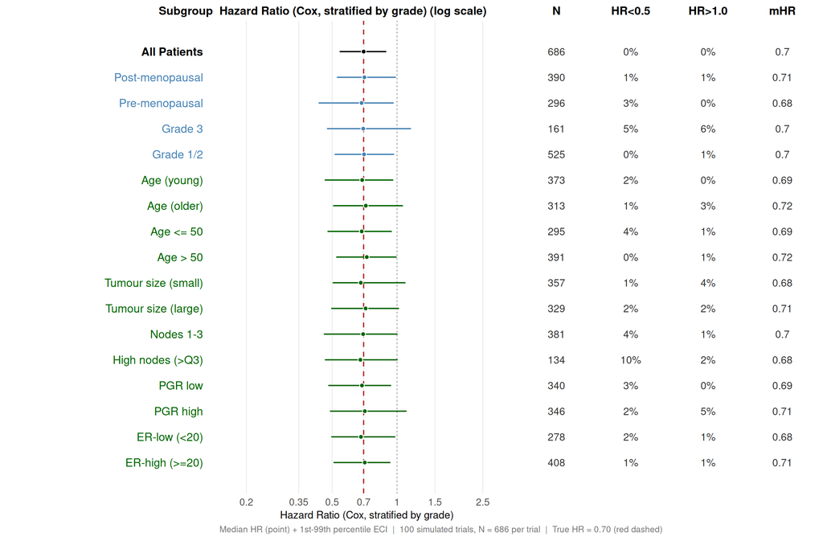

HR distribution — single-variable subgroups (log scale). Spread reflects sampling variability alone; all subgroups share the same true HR = 0.70.

```r
sg_single   <- sg_names[ok][idx_hr_single]
cat_single  <- cat_ok[ok][idx_hr_single]

gg_forest(
  subgroups   = sg_single,
  est         = hr_q[ok, 2][idx_hr_single],
  lo          = hr_q[ok, 1][idx_hr_single],
  hi          = hr_q[ok, 3][idx_hr_single],
  cat_vec     = cat_single,
  cat_colours = cat_cols,
  annot       = list(
    "N"      = as.character(mean_n[ok][idx_hr_single]),
    "HR<0.5" = paste0(round(100 * pr_hr_lt050[ok][idx_hr_single], 1), "%"),
    "HR>1.0" = paste0(round(100 * pr_hr_gt1[ok][idx_hr_single],   1), "%"),
    "mHR"    = mhr_uncond[ok][idx_hr_single]
  ),
  ref_line    = 0.70,
  vert_lines  = 1.00,
  ref_col     = "firebrick",
  vert_col    = "grey55",
  vert_lty    = "dotted",
  xlim        = c(0.15, 3.5),
  ticks_at    = c(0.20, 0.35, 0.50, 0.70, 1.00, 1.50, 2.50),
  xlog        = TRUE,
  xlab        = "Hazard Ratio (Cox, stratified by grade)",
  footnote    = paste0(
    "Median HR (point) + 1st-99th percentile ECI  |  ",
    n_sims_uniform, " simulated trials, N = ", nrow(gbsg), " per trial  |  ",
    "True HR = 0.70 (red dashed)"
  ),
  point_size  = fp_point_size,
  line_size   = fp_line_size,
  base_size   = fp_base_size,
  widths      = c(3.5, 5, 1.1, 1.2, 1.2, 1.1),
  clip_marker = "arrow"
)
```

**Panel B — HR distributions, combination and random-benchmark subgroups.** Note how the ECI widens sharply as subgroup N falls below ~60; the `random*` benchmarks (orange) define the noise floor for each size class.

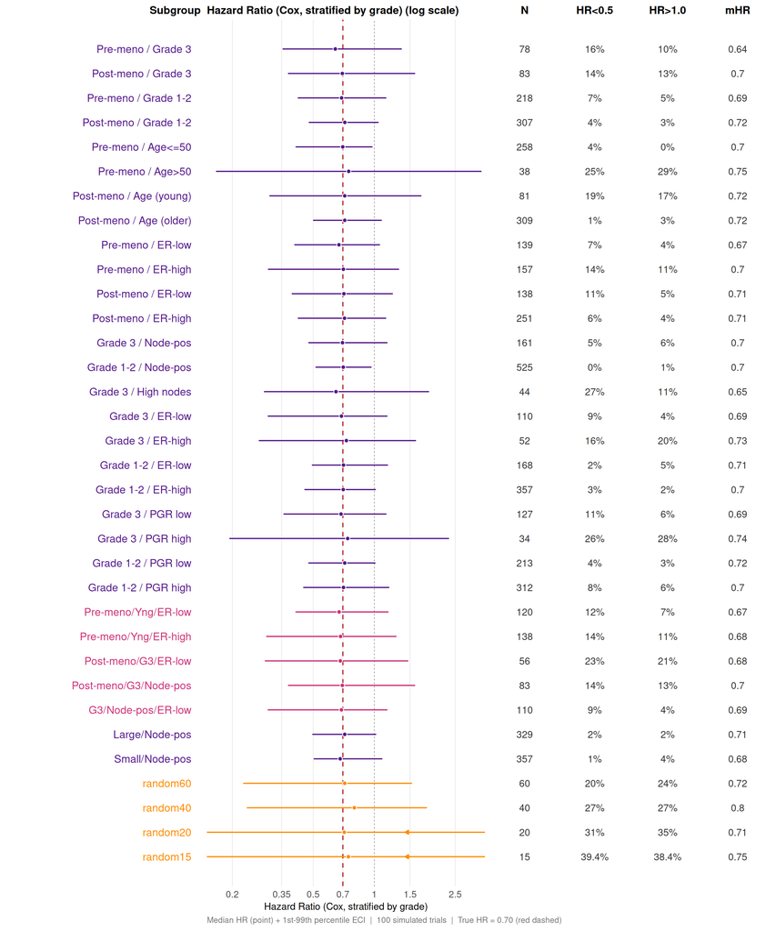

HR distribution — combination subgroups and random benchmarks (log scale). Random benchmarks of matching size (orange) are the baseline for chance variability.

```r
sg_combo   <- sg_names[ok][idx_hr_combo]
cat_combo  <- cat_ok[ok][idx_hr_combo]

gg_forest(
  subgroups   = sg_combo,
  est         = hr_q[ok, 2][idx_hr_combo],
  lo          = hr_q[ok, 1][idx_hr_combo],
  hi          = hr_q[ok, 3][idx_hr_combo],
  cat_vec     = cat_combo,
  cat_colours = cat_cols,
  annot       = list(
    "N"      = as.character(mean_n[ok][idx_hr_combo]),
    "HR<0.5" = paste0(round(100 * pr_hr_lt050[ok][idx_hr_combo], 1), "%"),
    "HR>1.0" = paste0(round(100 * pr_hr_gt1[ok][idx_hr_combo],   1), "%"),
    "mHR"    = mhr_uncond[ok][idx_hr_combo]
  ),
  ref_line    = 0.70,
  vert_lines  = 1.00,
  ref_col     = "firebrick",
  vert_col    = "grey55",
  vert_lty    = "dotted",
  xlim        = c(0.15, 3.5),
  ticks_at    = c(0.20, 0.35, 0.50, 0.70, 1.00, 1.50, 2.50),
  xlog        = TRUE,
  xlab        = "Hazard Ratio (Cox, stratified by grade)",
  footnote    = paste0(
    "Median HR (point) + 1st-99th percentile ECI  |  ",
    n_sims_uniform, " simulated trials  |  ",
    "True HR = 0.70 (red dashed)"
  ),
  point_size  = fp_point_size,
  line_size   = fp_line_size,
  base_size   = fp_base_size,
  widths      = c(3.5, 5, 1.1, 1.2, 1.2, 1.1),
  clip_marker = "arrow"
)
```

### 6.6.3 Forest plot: UB(HR) distributions

The upper confidence bound UB(HR) is the quantity a safety reviewer examines when asking whether a subgroup demonstrates harm or lack of benefit. The plots below show the distribution of UB(HR) across simulations in the same ECI format. Values above 1.0 (grey dotted line) represent trials where the confidence interval includes no treatment effect. The right-hand annotation columns show: the proportion of trials in which UB(HR) reaches each of two clinically meaningful thresholds (`UB>=2`, `UB>=3`), and the unconditional median UB(HR) across all trials (`mUB`).

**Panel A — UB(HR) distributions, single-variable subgroups.**

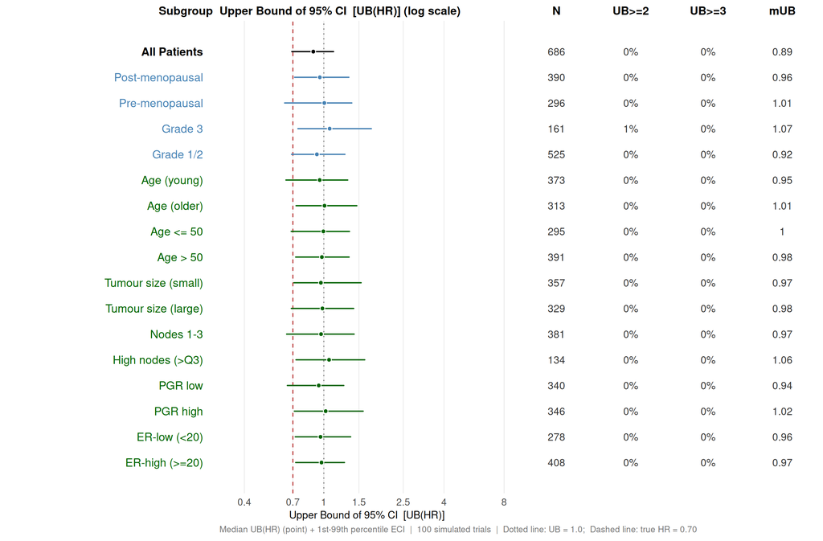

UB(HR) distribution — single-variable subgroups (log scale). Values right of HR = 1.0 (dotted line) represent trials failing to show significant benefit.

```r
sg_ub_s   <- sg_names[ok_ub][idx_ub_single]
cat_ub_s  <- cat_ok[ok_ub][idx_ub_single]

gg_forest(
  subgroups   = sg_ub_s,
  est         = ub_q[ok_ub, 2][idx_ub_single],
  lo          = ub_q[ok_ub, 1][idx_ub_single],
  hi          = ub_q[ok_ub, 3][idx_ub_single],
  cat_vec     = cat_ub_s,
  cat_colours = cat_cols,
  annot       = list(
    "N"     = as.character(mean_n[ok_ub][idx_ub_single]),
    "UB>=2" = paste0(round(100 * pr_ub_ge2[ok_ub][idx_ub_single], 1), "%"),
    "UB>=3" = paste0(round(100 * pr_ub_ge3[ok_ub][idx_ub_single], 1), "%"),
    "mUB"   = mub_uncond[ok_ub][idx_ub_single]
  ),
  ref_line    = 1.00,
  vert_lines  = 0.70,
  ref_col     = "grey55",
  ref_lty     = "dotted",
  vert_col    = "firebrick",
  vert_lty    = "dashed",
  xlim        = c(0.30, 9.0),
  ticks_at    = c(0.40, 0.70, 1.00, 1.50, 2.50, 4.00, 8.00),
  xlog        = TRUE,
  xlab        = "Upper Bound of 95% CI  [UB(HR)]",
  footnote    = paste0(
    "Median UB(HR) (point) + 1st-99th percentile ECI  |  ",
    n_sims_uniform, " simulated trials  |  ",
    "Dotted line: UB = 1.0;  Dashed line: true HR = 0.70"
  ),
  point_size  = fp_point_size,
  line_size   = fp_line_size,
  base_size   = fp_base_size,
  widths      = c(3.5, 5, 1.1, 1.2, 1.2, 1.1),
  clip_marker = "arrow"
)
```

**Panel B — UB(HR) distributions, combination subgroups and random benchmarks.** The `UB>=2` and `UB>=3` columns are the key safety quantities — they show how often a randomly-defined subgroup’s upper confidence bound crosses thresholds that a reviewer would treat as concerning, even though the true HR is 0.70 throughout.

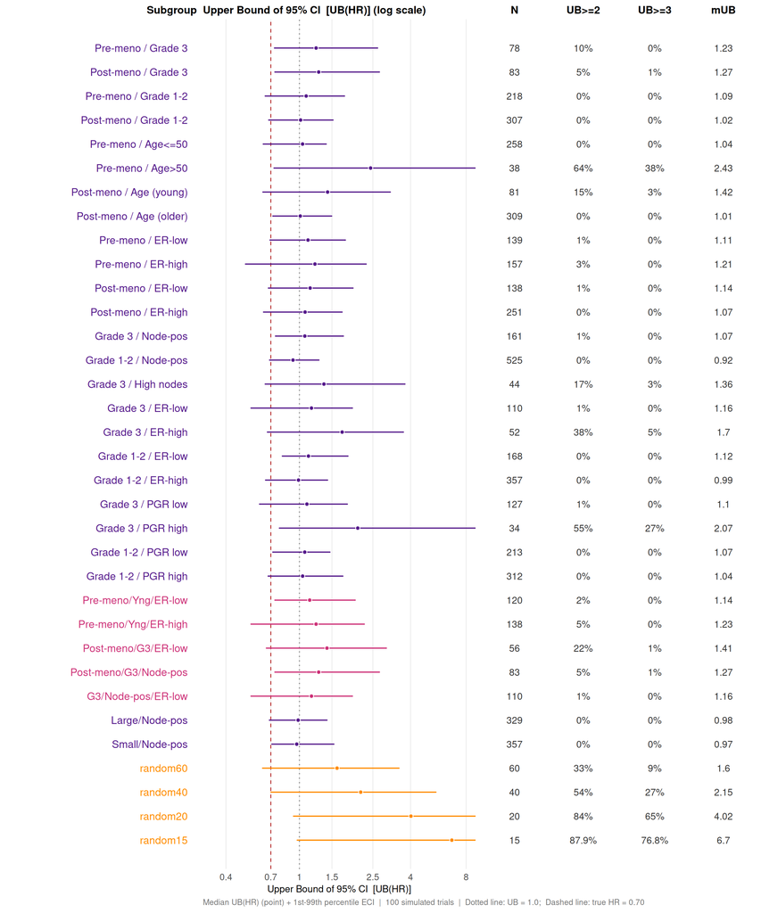

UB(HR) distribution — combination and random-benchmark subgroups. The widening ECI for small subgroups is the central message: chance alone produces UB(HR) > 3-5 for N ~ 15-40.

```r
sg_ub_c   <- sg_names[ok_ub][idx_ub_combo]
cat_ub_c  <- cat_ok[ok_ub][idx_ub_combo]

gg_forest(
  subgroups   = sg_ub_c,
  est         = ub_q[ok_ub, 2][idx_ub_combo],
  lo          = ub_q[ok_ub, 1][idx_ub_combo],
  hi          = ub_q[ok_ub, 3][idx_ub_combo],
  cat_vec     = cat_ub_c,
  cat_colours = cat_cols,
  annot       = list(
    "N"      = as.character(mean_n[ok_ub][idx_ub_combo]),
    "UB>=2"  = paste0(round(100 * pr_ub_ge2[ok_ub][idx_ub_combo], 1), "%"),
    "UB>=3"  = paste0(round(100 * pr_ub_ge3[ok_ub][idx_ub_combo], 1), "%"),
    "mUB"    = mub_uncond[ok_ub][idx_ub_combo]
  ),
  ref_line    = 1.00,
  vert_lines  = 0.70,
  ref_col     = "grey55",
  ref_lty     = "dotted",
  vert_col    = "firebrick",
  vert_lty    = "dashed",
  xlim        = c(0.30, 9.0),
  ticks_at    = c(0.40, 0.70, 1.00, 1.50, 2.50, 4.00, 8.00),
  xlog        = TRUE,
  xlab        = "Upper Bound of 95% CI  [UB(HR)]",
  footnote    = paste0(
    "Median UB(HR) (point) + 1st-99th percentile ECI  |  ",
    n_sims_uniform, " simulated trials  |  ",
    "Dotted line: UB = 1.0;  Dashed line: true HR = 0.70"
  ),
  point_size  = fp_point_size,
  line_size   = fp_line_size,
  base_size   = fp_base_size,
  widths      = c(3.5, 5, 1.1, 1.2, 1.2, 1.1),
  clip_marker = "arrow"
)
```

### 6.6.4 Forest plot: high-risk subgroups (Pr(UB ≥ 2.0) ≥ 10%)

The panels above present *all* pre-defined subgroups grouped by category. A complementary view is to filter to subgroups whose UB(HR) distribution crosses 2.0 with non-negligible frequency — concretely, those where at least 10% of simulated trials produce UB(HR) ≥ 2.0. These are the subgroups most likely to generate alarming-looking forest-plot rows by chance alone. **All Patients (ITT)** is always retained as a reference anchor, regardless of whether it meets the filter.

Rows are ordered with the ITT at the top, then the remaining subgroups in descending order of `Pr(UB>=2)` — so the most chance-prone subgroups appear immediately below the ITT for direct comparison.

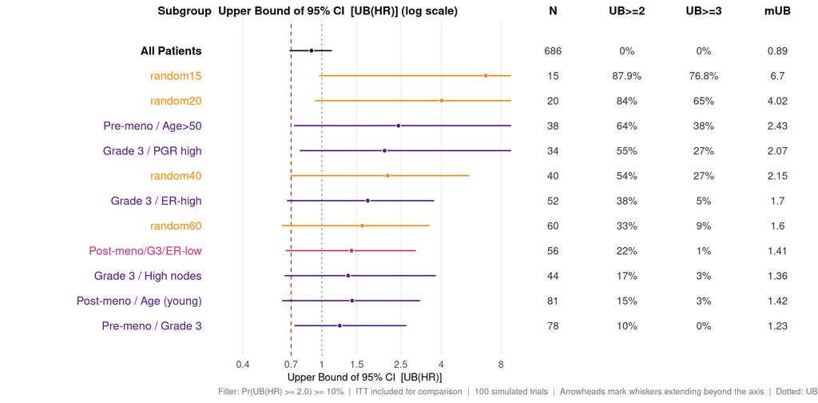

UB(HR) distribution — subgroups where at least 10% of simulated trials produce UB(HR) >= 2.0, with All Patients (ITT) for comparison. All share the same true HR = 0.70; differences are entirely sampling variability.

```r
sg_hr  <- sg_names[include_highrisk][ord_highrisk]
cat_hr <- cat_ok[include_highrisk][ord_highrisk]

gg_forest(
  subgroups   = sg_hr,
  est         = ub_q[include_highrisk, 2][ord_highrisk],
  lo          = ub_q[include_highrisk, 1][ord_highrisk],
  hi          = ub_q[include_highrisk, 3][ord_highrisk],
  cat_vec     = cat_hr,
  cat_colours = cat_cols,
  annot       = list(
    "N"      = as.character(mean_n[include_highrisk][ord_highrisk]),
    "UB>=2"  = paste0(round(100 * pr_ub_ge2[include_highrisk][ord_highrisk], 1), "%"),
    "UB>=3"  = paste0(round(100 * pr_ub_ge3[include_highrisk][ord_highrisk], 1), "%"),
    "mUB"    = mub_uncond[include_highrisk][ord_highrisk]
  ),
  ref_line    = 1.00,
  vert_lines  = 0.70,
  ref_col     = "grey55",
  ref_lty     = "dotted",
  vert_col    = "firebrick",
  vert_lty    = "dashed",
  xlim        = c(0.30, 9.0),
  ticks_at    = c(0.40, 0.70, 1.00, 1.50, 2.50, 4.00, 8.00),
  xlog        = TRUE,
  xlab        = "Upper Bound of 95% CI  [UB(HR)]",
  footnote    = paste0(
    "Filter: Pr(UB(HR) >= 2.0) >= ", round(100 * pr_thresh_highrisk), "%  |  ",
    "ITT included for comparison  |  ",
    n_sims_uniform, " simulated trials  |  ",
    "Arrowheads mark whiskers extending beyond the axis  |  ",
    "Dotted: UB = 1.0;  Dashed: true HR = 0.70"
  ),
  point_size  = fp_point_size,
  line_size   = fp_line_size,
  base_size   = fp_base_size,
  widths      = c(3.5, 5, 1.1, 1.2, 1.2, 1.1),
  clip_marker = "arrow"
)
```

The contrast is the point of the plot: every row shares the same true HR (0.70), yet the filtered subgroups produce UB(HR) values that are substantively different from the ITT. Because the filter is on a tail probability rather than on any clinical attribute, small subgroups populate this panel regardless of whether they were defined by a biomarker, a clinical interaction, or pure random sampling.

The companion view below is the *HR point-estimate distribution* for the same set of subgroups. Where the UB(HR) panel above asks “how alarming can the upper confidence bound look by chance?”, the HR panel asks “how misleading can the point estimate itself be?” The two views together complete the picture: small subgroups produce extreme results in both tails.

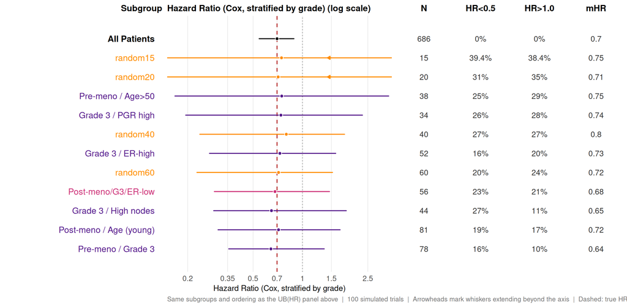

HR distribution — same high-risk subgroups as the panel above (Pr(UB(HR) >= 2.0) >= 10%, plus ITT for comparison). Every row shares the same true HR = 0.70 (red dashed); spread reflects sampling variability alone.

```r
gg_forest(
  subgroups   = sg_names[include_highrisk][ord_highrisk],
  est         = hr_q[include_highrisk, 2][ord_highrisk],
  lo          = hr_q[include_highrisk, 1][ord_highrisk],
  hi          = hr_q[include_highrisk, 3][ord_highrisk],
  cat_vec     = cat_ok[include_highrisk][ord_highrisk],
  cat_colours = cat_cols,
  annot       = list(
    "N"      = as.character(mean_n[include_highrisk][ord_highrisk]),
    "HR<0.5" = paste0(round(100 * pr_hr_lt050[include_highrisk][ord_highrisk], 1), "%"),
    "HR>1.0" = paste0(round(100 * pr_hr_gt1[include_highrisk][ord_highrisk], 1), "%"),
    "mHR"    = mhr_uncond[include_highrisk][ord_highrisk]
  ),
  ref_line    = 0.70,
  vert_lines  = 1.00,
  ref_col     = "firebrick",
  ref_lty     = "dashed",
  vert_col    = "grey55",
  vert_lty    = "dotted",
  xlim        = c(0.15, 3.5),
  ticks_at    = c(0.20, 0.35, 0.50, 0.70, 1.00, 1.50, 2.50),
  xlog        = TRUE,
  xlab        = "Hazard Ratio (Cox, stratified by grade)",
  footnote    = paste0(
    "Same subgroups and ordering as the UB(HR) panel above  |  ",
    n_sims_uniform, " simulated trials  |  ",
    "Arrowheads mark whiskers extending beyond the axis  |  ",
    "Dashed: true HR = 0.70;  Dotted: HR = 1.0"
  ),
  point_size  = fp_point_size,
  line_size   = fp_line_size,
  base_size   = fp_base_size,
  widths      = c(3.5, 5, 1.1, 1.2, 1.2, 1.1),
  clip_marker = "arrow"
)
```

Read together with the UB(HR) panel, the message is direct: the same small subgroups that produce large upper bounds also routinely produce point estimates that overstate (HR < 0.5) or understate (HR > 1.0) the true effect. None of this reflects genuine heterogeneity — the DGM guarantees a uniform HR of 0.70 for every patient.

# 7 Summary

| Step | Function | Purpose |
| --- | --- | --- |
| 1 | — | Convert source data to consistent time scale |
| 2 | `generate_aft_dgm_flex()` | Fit AFT model; embed harm subgroup; build super population |
| 3 | `check_censoring_dgm()` | Verify simulated censoring matches source data |
| 4 | `calibrate_cens_adjust()` | Find `cens_adjust` that aligns censoring rate or KM median |
| 5 | `simulate_from_dgm()` | Draw individual synthetic trials from the DGM |
| 6 | `forestsearch()` + summaries | Apply method and accumulate operating characteristics |

### 7.0.1 Timing summary

Wall-clock time for each computational stage and a projection for larger simulation budgets. The simulation loop dominates and scales linearly in `n_sims_uniform`; the DGM and censoring-calibration steps are one-time costs that don’t change with replicate count.

Timing for n_sims_uniform = 100, parallel across 116 of 128 cores.

| Step | Elapsed | Per trial |
| --- | --- | --- |
| DGM construction (generate_aft_dgm_flex) | 79 ms | — |
| Censoring calibration (calibrate_cens_adjust) | 452 ms | — |
| Simulation loop (100 trials × 56 subgroups, 116 workers) | 5.02 sec | 50 ms |
| Total | 5.55 sec | — |

```
Throughput: 19.9 trials/sec (wall-clock, 116 workers)  |  Projected total time:  1,000 sims → 50.69 sec    │    5,000 sims → 4.2 min
```

# 8 Appendix: DGM with Heterogeneous Treatment Effects

The main vignette uses a **uniform-effect DGM** (`model = "null"`): every patient shares the same true HR = 0.70, and any apparent subgroup finding is a false positive. This appendix illustrates the alternative case — a DGM with **genuine heterogeneous treatment effects (HTE)**, where a specific subgroup of patients experiences a different (smaller or larger) treatment effect than the rest of the population.

`generate_aft_dgm_flex()` supports HTE via `model = "alt"` combined with `subgroup_vars`, `subgroup_cuts`, and the interaction modifier `k_inter`. The example below embeds a **harm subgroup** defined by ER-low (`er ≤ 20`) and pre-menopausal (`meno == 0`) status, with the interaction strength chosen so the within-harm-subgroup HR is materially attenuated relative to the no-harm complement.

```r
set.seed(42)

dgm_hte <- generate_aft_dgm_flex(
  # ── Required: source data & outcome ─────────────────────────────────────
  data                = gbsg,
  continuous_vars     = c("age", "size", "nodes", "pgr", "er"),
  factor_vars         = c("meno", "grade"),
  outcome_var         = "time_months",
  event_var           = "status",
  # ── Treatment ───────────────────────────────────────────────────────────
  treatment_var       = "hormon",
  draw_treatment      = FALSE,                                  # default
  # ── HTE specification — embedded harm subgroup ──────────────────────────
  model               = "alt",                                  # alternative DGM (HTE)
  subgroup_vars       = c("er", "meno"),
  subgroup_cuts       = list(er = 20, meno = 0),                # ER-low & pre-menopausal
  k_treat             = 1,                                      # default
  k_inter             = 1.5,                                    # moderate interaction
  spline_spec         = NULL,                                   # default
  set_beta_spec       = list(set_var = NULL, beta_var = NULL),  # default
  # ── Censoring model ─────────────────────────────────────────────────────
  continuous_vars_cens = NULL,                                  # default → inherit
  factor_vars_cens     = NULL,                                  # default → inherit
  select_censoring     = TRUE,                                  # default — AIC select
  cens_type            = "weibull",                             # default
  cens_params          = list(),                                # default
  cens_intercept_only  = FALSE,                                 # default
  # ── Super population & misc ─────────────────────────────────────────────
  n_super             = 5000,
  standardize         = FALSE,                                  # default
  seed                = 42,
  verbose             = FALSE
)
```

```r
cat("=== HTE DGM Summary ===\n")
```

```
=== HTE DGM Summary ===
```

```r
cat("Time scale          : months\n")
```

```
Time scale          : months
```

```r
cat("Implied median T    : exp(mu) =",
    round(exp(dgm_hte$model_params$mu), 1), "months\n")
```

```
Implied median T    : exp(mu) = 57.8 months
```

```r
cat("Subgroup proportion :", round(dgm_hte$subgroup_info$proportion, 3), "\n")
```

```
Subgroup proportion : 0.188
```

```r
cat("True HR (harm)      :",
    round(dgm_hte$hazard_ratios$harm_subgroup, 3), "\n")
```

```
True HR (harm)      : 1.206
```

```r
cat("True HR (no harm)   :",
    round(dgm_hte$hazard_ratios$no_harm_subgroup, 3), "\n")
```

```
True HR (no harm)   : 0.729
```

```r
cat("True HR (overall)   :",
    round(dgm_hte$hazard_ratios$overall, 3), "\n")
```

```
True HR (overall)   : 0.781
```

```r
cat("Censoring type      :",
    dgm_hte$model_params$censoring$type, "\n")
```

```
Censoring type      : weibull
```

## 8.1 Calibration and a single trial

Calibration follows the same procedure as in Part II — only the DGM object changes. We reuse `sim_config` so the per-trial pipeline parameters (`analysis_time`, `max_entry`) are identical to the main analysis.

```r
cal_hte <- calibrate_cens_adjust(
  dgm           = dgm_hte,
  target        = "rate",
  n             = 1000,
  rand_ratio    = 1,                            # default
  analysis_time = sim_config$analysis_time,
  max_entry     = sim_config$max_entry,
  seed          = 42,
  interval      = c(-3, 3),                     # default
  tol           = 1e-4,                         # default
  n_eval        = 2000,
  verbose       = FALSE
)

cat("Calibrated cens_adjust :", round(cal_hte$cens_adjust, 4), "\n")
```

```
Calibrated cens_adjust : 0.0344
```

```r
cat("Achieved censoring rate:", round(cal_hte$sim_value,   3), "\n")
```

```
Achieved censoring rate: 0.552
```

```r
sim_hte <- simulate_from_dgm(
  dgm            = dgm_hte,
  n              = 600,
  rand_ratio     = 1,
  entry_var      = NULL,                       # default
  max_entry      = sim_config$max_entry,
  analysis_time  = sim_config$analysis_time,
  cens_adjust    = cal_hte$cens_adjust,
  draw_treatment = TRUE,                       # default
  seed           = 100,
  strata_rand    = NULL,                       # default
  hrz_crit       = NULL,                       # default
  keep_rand      = FALSE,                      # default
  time_eos       = NULL                        # default
)

cat("Simulated HTE trial:  N =", nrow(sim_hte), "\n")
```

```
Simulated HTE trial:  N = 600
```

```r
cat("Harm-subgroup size :", sum(sim_hte$flag_harm == 1),
    " (", round(100 * mean(sim_hte$flag_harm), 1), "% of trial)\n", sep = "")
```

```
Harm-subgroup size :114 (19% of trial)
```

```r
cat("Overall event rate :", round(mean(sim_hte$event_sim), 3), "\n")
```

```
Overall event rate : 0.412
```

```r
cat("Event rate (harm subgroup):",
    round(mean(sim_hte$event_sim[sim_hte$flag_harm == 1]), 3), "\n")
```

```
Event rate (harm subgroup): 0.57
```

```r
cat("Event rate (no-harm)      :",
    round(mean(sim_hte$event_sim[sim_hte$flag_harm == 0]), 3), "\n")
```

```
Event rate (no-harm)      : 0.374
```

## 8.2 True vs observed HR by subgroup

Fitting unstratified Cox models within each true subgroup recovers the embedded heterogeneity — the harm subgroup’s observed HR is materially higher than the no-harm complement’s.

```r
cox_all_hte    <- coxph(Surv(y_sim, event_sim) ~ treat_sim, data = sim_hte)
cox_harm_hte   <- coxph(Surv(y_sim, event_sim) ~ treat_sim,
                        data = subset(sim_hte, flag_harm == 1))
cox_noharm_hte <- coxph(Surv(y_sim, event_sim) ~ treat_sim,
                        data = subset(sim_hte, flag_harm == 0))

results_hte <- data.frame(
  Subgroup    = c("ITT", "Harm (true)", "No-harm (true)"),
  N           = c(nrow(sim_hte),
                  sum(sim_hte$flag_harm == 1),
                  sum(sim_hte$flag_harm == 0)),
  True_HR     = round(c(dgm_hte$hazard_ratios$overall,
                        dgm_hte$hazard_ratios$harm_subgroup,
                        dgm_hte$hazard_ratios$no_harm_subgroup), 3),
  Observed_HR = round(exp(c(coef(cox_all_hte),
                            coef(cox_harm_hte),
                            coef(cox_noharm_hte))), 3)
)
print(results_hte, row.names = FALSE)
```

```
       Subgroup   N True_HR Observed_HR
            ITT 600   0.781       0.984
    Harm (true) 114   1.206       2.232
 No-harm (true) 486   0.729       0.782
```

## 8.3 Kaplan–Meier curves by subgroup

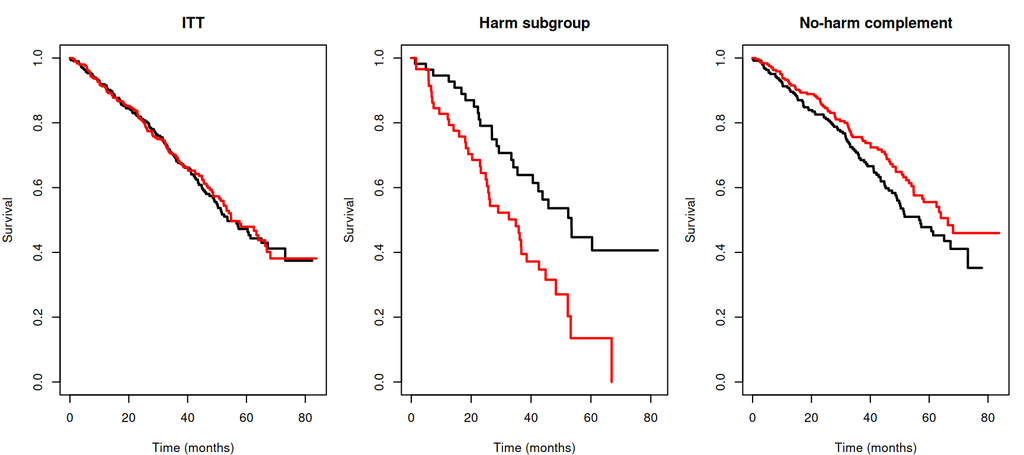

```r
op <- par(mfrow = c(1, 3), mar = c(4, 4, 3, 1))

plot(survfit(Surv(y_sim, event_sim) ~ treat_sim, data = sim_hte),
     col = c("black", "red"), lwd = 2,
     xlab = "Time (months)", ylab = "Survival",
     main = "ITT")
plot(survfit(Surv(y_sim, event_sim) ~ treat_sim,
             data = subset(sim_hte, flag_harm == 1)),
     col = c("black", "red"), lwd = 2,
     xlab = "Time (months)", ylab = "Survival",
     main = "Harm subgroup")
plot(survfit(Surv(y_sim, event_sim) ~ treat_sim,
             data = subset(sim_hte, flag_harm == 0)),
     col = c("black", "red"), lwd = 2,
     xlab = "Time (months)", ylab = "Survival",
     main = "No-harm complement")
```

```r
par(op)
```

This appendix DGM is a useful target for evaluating subgroup-discovery methods (such as `forestsearch()`): we know the true harm subgroup by construction and can measure whether the method recovers it.